# **Regression Project: Boston House Price Prediction**

# **Marks: 60**

Welcome to the project on regression. We will use the **Boston house price dataset** for this project.

## **Objective**

The problem at hand is to **predict the housing prices of a town or a suburb based on the features of the locality provided to us**. In the process, we need to **identify the most important features affecting the price of the house**. We need to employ techniques of data preprocessing and build a linear regression model that predicts the prices for the unseen data.

## **Dataset**

Each record in the database describes a house in Boston suburb or town. The data was drawn from the Boston Standard Metropolitan Statistical Area (SMSA) in 1970. Detailed attribute information can be found below:

Attribute Information:

- **CRIM:** Per capita crime rate by town
- **ZN:** Proportion of residential land zoned for lots over 25,000 sq.ft.
- **INDUS:** Proportion of non-retail business acres per town
- **CHAS:** Charles River dummy variable (= 1 if tract bounds river; 0 otherwise)
- **NOX:** Nitric Oxide concentration (parts per 10 million)
- **RM:** The average number of rooms per dwelling
- **AGE:** Proportion of owner-occupied units built before 1940
- **DIS:** Weighted distances to five Boston employment centers
- **RAD:** Index of accessibility to radial highways
- **TAX:** Full-value property-tax rate per 10,000 dollars
- **PTRATIO:** Pupil-teacher ratio by town
- **LSTAT:** % lower status of the population
- **MEDV:** Median value of owner-occupied homes in 1000 dollars

## **Importing the necessary libraries**

```python
# Libraries to help with reading and manipulating data
import numpy as np
import pandas as pd
# Libaries to help with data visualization
import matplotlib.pyplot as plt
import seaborn as sns
#libraries for building a linear model
from statsmodels.formula.api import ols
import statsmodels.api as sm
from sklearn.linear_model import LinearRegression
# Import library for preparing data
from sklearn.model_selection import train_test_split
# Import library for data preprocessing
from sklearn.preprocessing import MinMaxScaler
from sklearn.preprocessing import StandardScaler
import warnings
warnings.filterwarnings("ignore")
```

### Loading the dataset

Our data type is CSV, so I will use the pandas read_csv() function.

```python
#import the data
data = pd.read_csv("/content/Boston.csv")
#copying the dataset
df = data.copy()
```

## Data Overview

- Observations
- Sanity checks

```python
#viewing the first 5 rows
df.head(5)
```

|  | CRIM | ZN | INDUS | CHAS | NOX | RM | AGE | DIS | RAD | TAX | PTRATIO | LSTAT | MEDV |
| --- | --- | --- | --- | --- | --- | --- | --- | --- | --- | --- | --- | --- | --- |
| 0 | 0.00632 | 18.0 | 2.31 | 0 | 0.538 | 6.575 | 65.2 | 4.0900 | 1 | 296 | 15.3 | 4.98 | 24.0 |
| 1 | 0.02731 | 0.0 | 7.07 | 0 | 0.469 | 6.421 | 78.9 | 4.9671 | 2 | 242 | 17.8 | 9.14 | 21.6 |
| 2 | 0.02729 | 0.0 | 7.07 | 0 | 0.469 | 7.185 | 61.1 | 4.9671 | 2 | 242 | 17.8 | 4.03 | 34.7 |
| 3 | 0.03237 | 0.0 | 2.18 | 0 | 0.458 | 6.998 | 45.8 | 6.0622 | 3 | 222 | 18.7 | 2.94 | 33.4 |
| 4 | 0.06905 | 0.0 | 2.18 | 0 | 0.458 | 7.147 | 54.2 | 6.0622 | 3 | 222 | 18.7 | 5.33 | 36.2 |

Alright, let's use the info() function to look at shape of our data frame, the data types of our features, and more.

```python
#checking the data type of the column for the dataset
df.info()
```

```
<class 'pandas.core.frame.DataFrame'>
RangeIndex: 506 entries, 0 to 505
Data columns (total 13 columns):
 #   Column   Non-Null Count  Dtype
---  ------   --------------  -----
 0   CRIM     506 non-null    float64
 1   ZN       506 non-null    float64
 2   INDUS    506 non-null    float64
 3   CHAS     506 non-null    int64
 4   NOX      506 non-null    float64
 5   RM       506 non-null    float64
 6   AGE      506 non-null    float64
 7   DIS      506 non-null    float64
 8   RAD      506 non-null    int64
 9   TAX      506 non-null    int64
 10  PTRATIO  506 non-null    float64
 11  LSTAT    506 non-null    float64
 12  MEDV     506 non-null    float64
dtypes: float64(10), int64(3)
memory usage: 51.5 KB
```

**Observation:**

- there are 506 instances in this dataset. no missing value.
- All attributes are numerical and no need to preform any manipulation.

```python
#checking the shape of the dataset
df.shape
```

```
(506, 13)
```

**Observation:**

In this dataset; I have 13 columns and 506 rows.

### Checking for missing values in the dataset

```python
#checking for missing value
df.isnull().sum()
```

```
CRIM       0
ZN         0
INDUS      0
CHAS       0
NOX        0
RM         0
AGE        0
DIS        0
RAD        0
TAX        0
PTRATIO    0
LSTAT      0
MEDV       0
dtype: int64
```

```python
#checking any duplicate data
df.duplicated().sum()
```

```
0
```

**Observation:**

no missing data or duplicate found.

### Checking the statistical summary for the dataset

```python
#checking the statistical summary
df.describe(include = "all").T
```

|  | count | mean | std | min | 25% | 50% | 75% | max |
| --- | --- | --- | --- | --- | --- | --- | --- | --- |
| CRIM | 506.0 | 3.613524 | 8.601545 | 0.00632 | 0.082045 | 0.25651 | 3.677083 | 88.9762 |
| ZN | 506.0 | 11.363636 | 23.322453 | 0.00000 | 0.000000 | 0.00000 | 12.500000 | 100.0000 |
| INDUS | 506.0 | 11.136779 | 6.860353 | 0.46000 | 5.190000 | 9.69000 | 18.100000 | 27.7400 |
| CHAS | 506.0 | 0.069170 | 0.253994 | 0.00000 | 0.000000 | 0.00000 | 0.000000 | 1.0000 |
| NOX | 506.0 | 0.554695 | 0.115878 | 0.38500 | 0.449000 | 0.53800 | 0.624000 | 0.8710 |
| RM | 506.0 | 6.284634 | 0.702617 | 3.56100 | 5.885500 | 6.20850 | 6.623500 | 8.7800 |
| AGE | 506.0 | 68.574901 | 28.148861 | 2.90000 | 45.025000 | 77.50000 | 94.075000 | 100.0000 |
| DIS | 506.0 | 3.795043 | 2.105710 | 1.12960 | 2.100175 | 3.20745 | 5.188425 | 12.1265 |
| RAD | 506.0 | 9.549407 | 8.707259 | 1.00000 | 4.000000 | 5.00000 | 24.000000 | 24.0000 |
| TAX | 506.0 | 408.237154 | 168.537116 | 187.00000 | 279.000000 | 330.00000 | 666.000000 | 711.0000 |
| PTRATIO | 506.0 | 18.455534 | 2.164946 | 12.60000 | 17.400000 | 19.05000 | 20.200000 | 22.0000 |
| LSTAT | 506.0 | 12.653063 | 7.141062 | 1.73000 | 6.950000 | 11.36000 | 16.955000 | 37.9700 |
| MEDV | 506.0 | 22.532806 | 9.197104 | 5.00000 | 17.025000 | 21.20000 | 25.000000 | 50.0000 |

**Observation:**

- looking at the statistical summary; there is a big gap between the min and the max for each feature this might indicate an outliers for some of them.
- CHAS: Charles River feature shows a few towns near the river and the majority not border with it.
- DIS feature shows min as 1.12 and max as 12.12 means some of the houses are far from the five Boston employment centers
- MEDV feature shows the min as 5 and the max is 50 which might show there is a wide range of home values.

## Exploratory Data Analysis (EDA)

- EDA is an important part of any project involving data.
- It is important to investigate and understand the data better before building a model with it.
- A few questions have been mentioned below which will help you approach the analysis in the right manner and generate insights from the data.
- A thorough analysis of the data, in addition to the questions mentioned below, should be done.

**Questions:**

1. What does the distribution of 'MEDV' look like?
2. What can we infer form the correlation heatmap? Is there correlation between the dependent and independent variables?
3. What are all the inferences that can be found by doing univariate analysis for different variables?
4. Do bivariate analysis to visualize the relationship between the features having significant correlations (>= 0.7 or <= -0.7)

## Univariate analysis

Let's look at each numerical variable. What are all the inferences that can be found by doing univariate analysis for different variables?

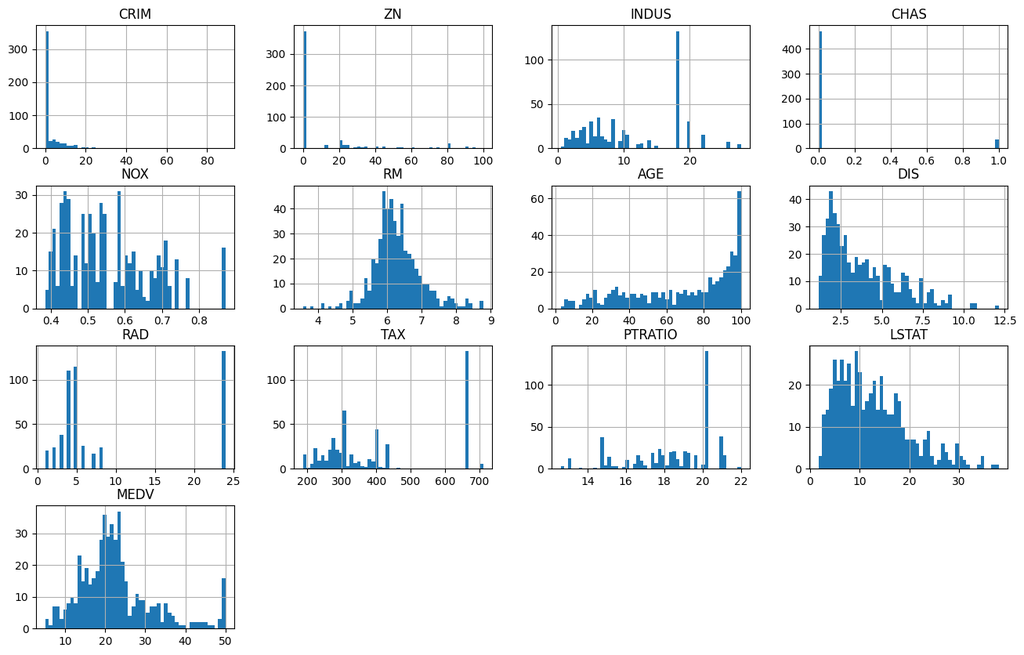

```python
#looking at the distribution of all the features
%matplotlib inline
import matplotlib.pyplot as plt
df.hist(bins=50, figsize=(16,10))
plt.show()
```

**Observation:**

- These attributes have very different scales going to do feature scaling.
- MEDV has a right skewed and we need to treat it.

```python
#using this def (got it from the optional class under machine learning)
def histogram_boxplot(df, feature, figsize = (12, 7), kde = False, bins = None):
    f2, (ax_box2, ax_hist2) = plt.subplots(
        nrows = 2,
        sharex = True,
        gridspec_kw = {'height_ratios': (0.25, 0.75)},
        figsize = figsize,
    )
    sns.boxplot(
        data = df,
        x = feature, ax = ax_box2, showmeans = True, color = 'orange'
    )
    sns.histplot(
        data = df,
        x = feature, kde = kde, ax = ax_hist2, bins = bins, palette = 'green'
    ) if bins else sns.histplot(
        data = df,
        x = feature, kde = kde, ax = ax_hist2
    )

    ax_hist2.axvline(
        df[feature].mean(), color = 'blue', linestyle = '--'
    )
    ax_hist2.axvline(
        df[feature].median(), color = 'red', linestyle = '-'
    )
```

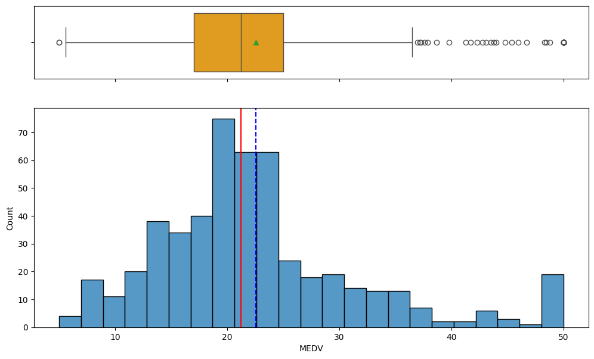

```python
#What does the distribution of 'MEDV' look like?
histogram_boxplot(df, 'MEDV')
```

**Observation:**

- The MEDV distributed is skewed sightly to the right with mean lying around 22 and median lying around 21.
- will apply a log transformation to it.

### Log transformation of our target

```python
#apply log transformation to our target (MEDV)
df['MEDV_log'] = np.log(df['MEDV'])
```

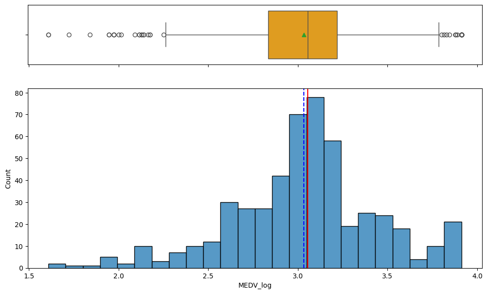

```python
#lets check the distribuation again
histogram_boxplot(df, 'MEDV_log')
```

**Observation:**

- our target now looks more normal and we need to drop both before training our model

What are all the inferences that can be found by doing univariate analysis for different variables?

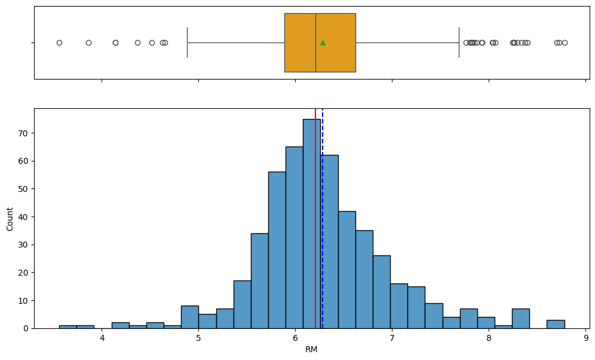

```python
histogram_boxplot(df, 'RM')
```

**Observation:**

- The RM is normally distributed with mean and median around 6.2

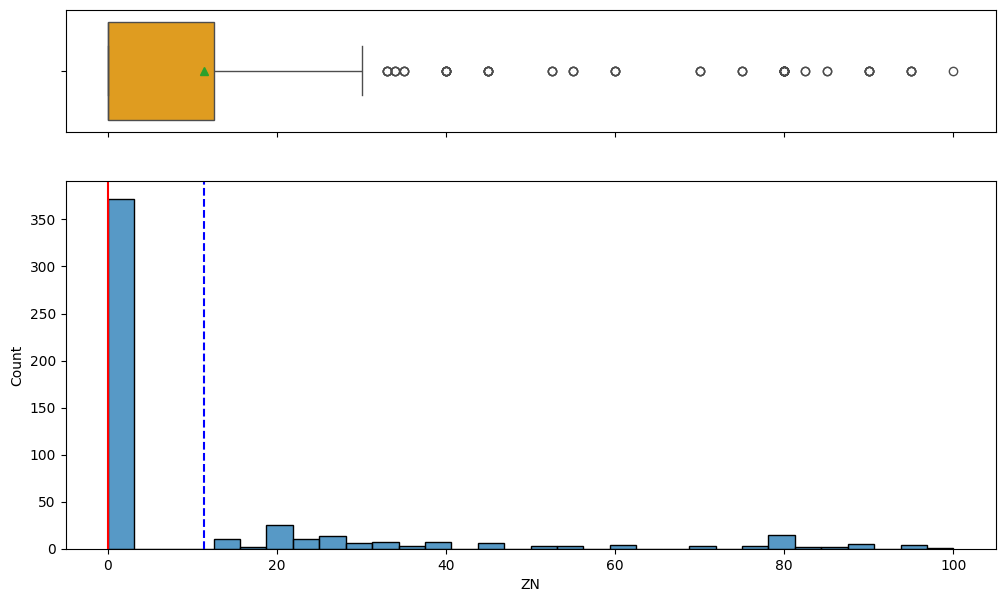

```python
histogram_boxplot(df, 'ZN')
```

**Observation:**

- The ZN distribution is skewed to the right with the median lying at zero and mean around 11.3.
- Since the median lying at zero proportion of residential land zoned for lots is less than 25,000 sq.ft.

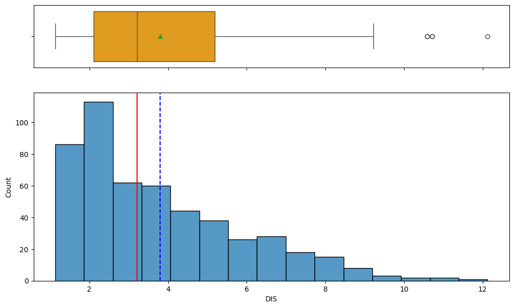

```python
histogram_boxplot(df, 'DIS')
```

**Observation:**

- The DIS distribution is skewed to the right with the median lying around 3.2 and mean around 3.7.

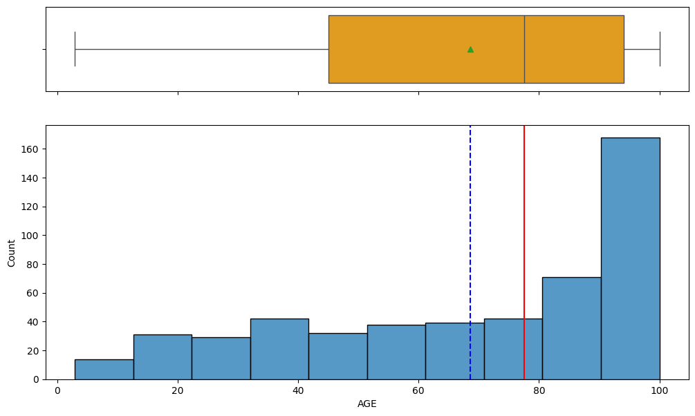

```python
histogram_boxplot(df, 'AGE')
```

**Observation:**

- The AGE distributed is skewed to the left with mean lying around 68 and median lying around 77.5.

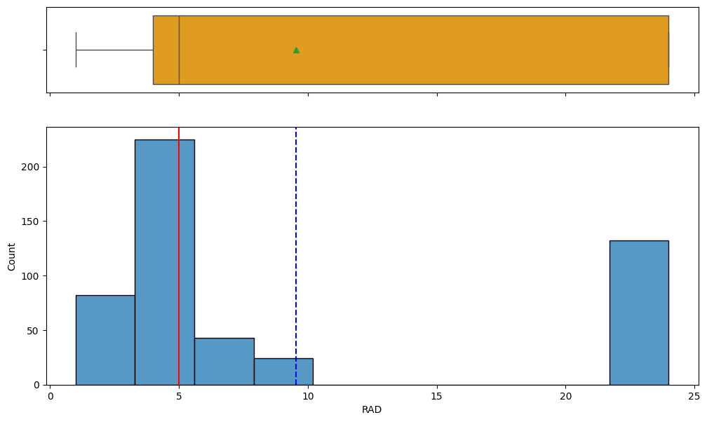

```python
histogram_boxplot(df, 'RAD')
```

**Observation:**

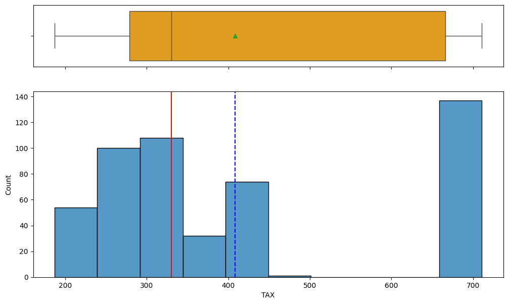

```python
histogram_boxplot(df, 'TAX')
```

**Observation:**

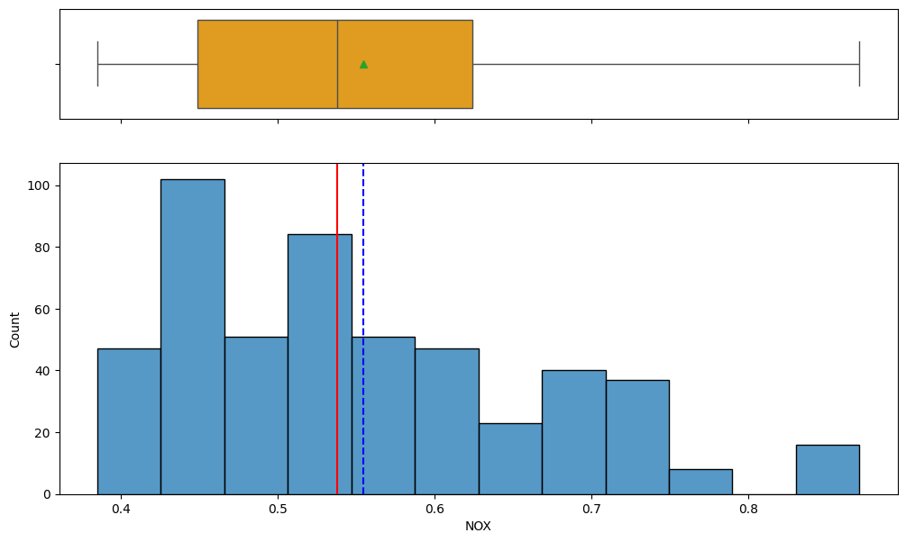

```python
histogram_boxplot(df, 'NOX')
```

**Observation:**

- The NOX distribution is skewed to the right with the median lying around 0.5 and mean around 0.53.

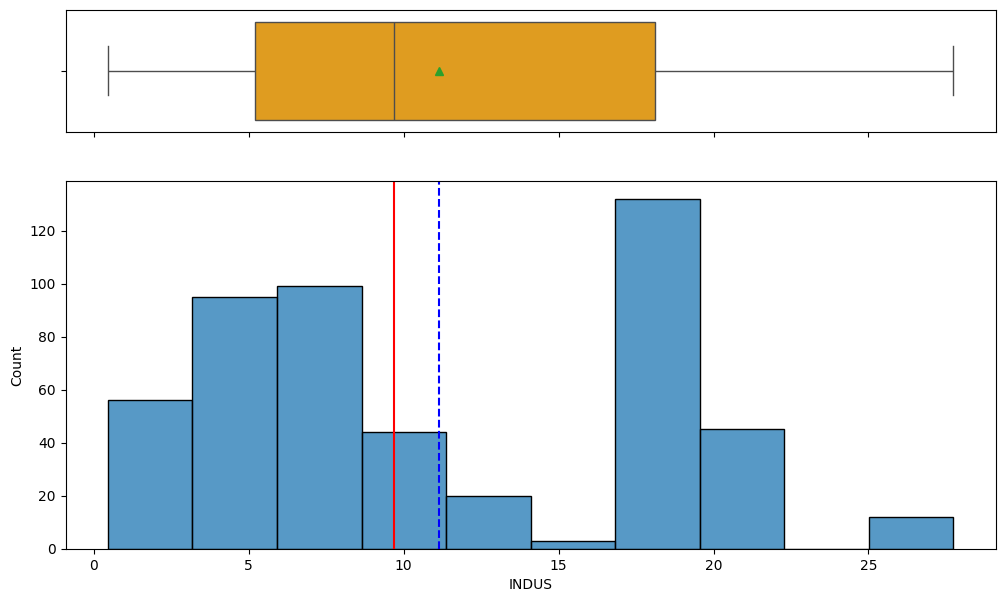

```python
histogram_boxplot(df, 'INDUS')
```

**Observation:**

- The INDUS distributed is skewed to the right with mean lying around 11 and median lying around 9.

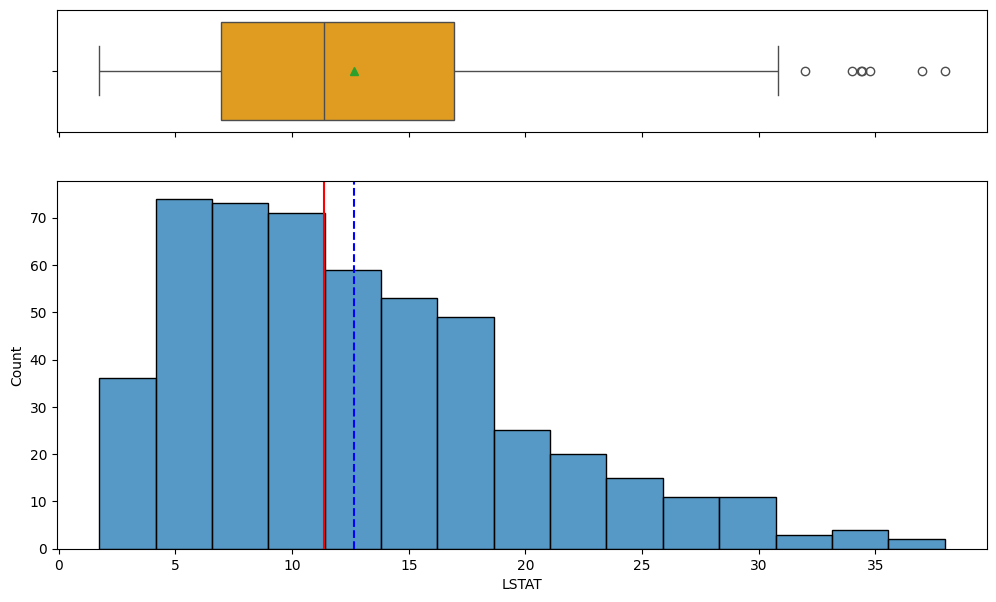

```python
histogram_boxplot(df, 'LSTAT')
```

**Observation:**

- The LSTAT distributed is skewed to the right with mean lying around 12.6 and median lying around 11.3.

## Bivariate analysis

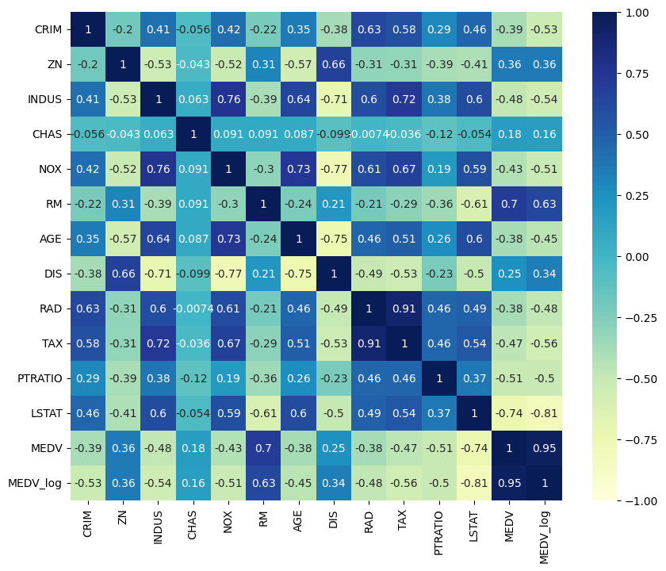

```python
#What can we infer form the correlation heatmap? Is there correlation between the dependent and independent variables?
# lets see a correlation on a heat map.
plt.subplots(figsize=(10,8))
dataplot = sns.heatmap(df.corr(), vmin = -1, vmax = 1, cmap='YlGnBu', annot=True)
# displaying heatmap
plt.show()
```

**Observation:**

- There is a high correlation between the dependent (MEDV) and independent feature (RM)
- MEDV has a negative correlation with LSTAT.

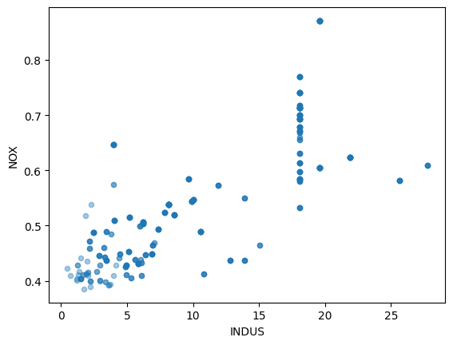

```python
#Do bivariate analysis to visualize the relationship between the features having significant correlations (>= 0.7 or <= -0.7)
#there is a correlation >=0.7 between NOX&INDUS , TAX&INDUS, RAD&TAX, AGE&NOX
#let's look into each one
#NOX&INDUS
df.plot(kind='scatter', x='INDUS', y='NOX', alpha=0.4)
plt.show()
```

**Observation:**

- the positive correlation indicates the areas with higher industrial activity (INDUS) tend to have higher levels of pollution (NOX)

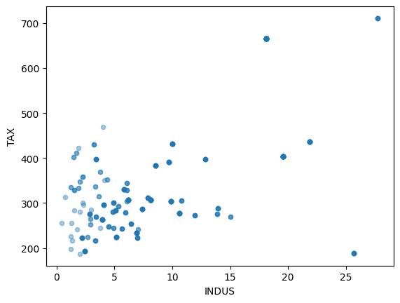

```python
#let's look into TAX&INDUS
df.plot(kind='scatter', x='INDUS', y='TAX', alpha=0.4)
plt.show()
```

**Observation:**

- the positive correlation indicates the areas with higher industrial activity (INDUS) tend to have higher taxes to pay(TAX) which has a correlation with (NOX) as well.

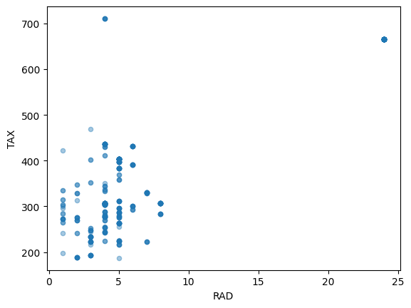

```python
#let's look into RAD&TAX
df.plot(kind='scatter', x='RAD', y='TAX', alpha=0.4)
plt.show()
```

**Observation:**

- there is a high correlation but no trend between them and both have outliers as was clear in Univariate analysis.

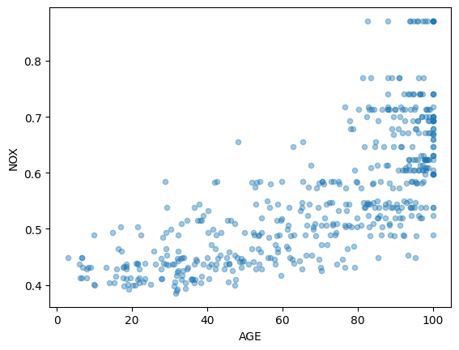

```python
#let's look into AGE&NOX
df.plot(kind='scatter', x='AGE', y='NOX', alpha=0.4)
plt.show()
```

**Observation:**

- there is a high correlation between homes that built before 1940 and the level of Nox.

**Let's look at the distribution of our target variable MEDV with the numeric variables

```python
#lets look at the correlation between MEDV and the rest
corr_matrix = df.corr()
corr_matrix["MEDV"].sort_values(ascending=False)
```

```
MEDV        1.000000
MEDV_log    0.953155
RM          0.695360
ZN          0.360445
DIS         0.249929
CHAS        0.175260
AGE        -0.376955
RAD        -0.381626
CRIM       -0.388305
NOX        -0.427321
TAX        -0.468536
INDUS      -0.483725
PTRATIO    -0.507787
LSTAT      -0.737663
Name: MEDV, dtype: float64
```

**Observation:**

- looking at the numbers there are significant relationships among few independent variables with our target we need to drop some of them before training our model.

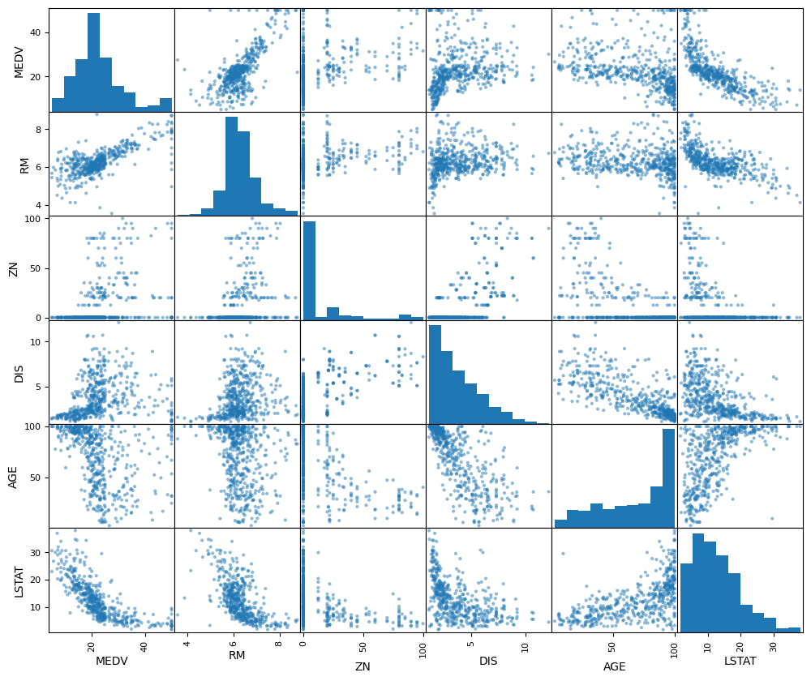

```python
#lets get a quick look at the positive corelation between our target and indpendent variable
from pandas.plotting import scatter_matrix
attributes = ['MEDV', 'RM','ZN','DIS','AGE','LSTAT']
scatter_matrix(df[attributes], figsize = (12, 10))
plt.show()
```

**Observation:**

- the most promising attribute to predict the MEDV is RM, so lets zoom in on their correlation using scatterplot.
- there is a positive correlation between LSTAT and AGE but negative with DIS.
- on the other hand MEDV and LSTAT has a negative correlation will zoom in on their as well.
- LSTAT and RM has a negative correlation.

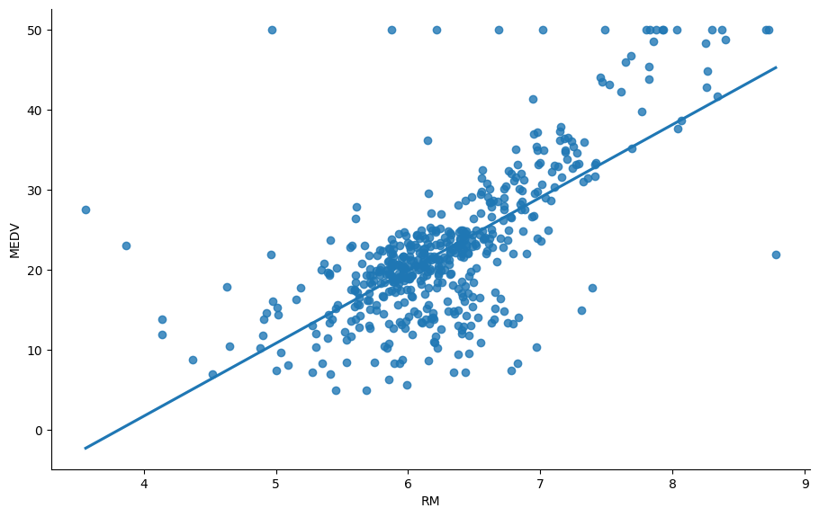

```python
#looking at the correlation between MEDV and RM
sns.lmplot(x = 'RM', y = 'MEDV', data = df, fit_reg = True, ci = None)
fig = plt.gcf()
fig.set_size_inches(10, 6)
plt.show()
```

**Observation:**

- MEDV: Median value of owner-occupied homes and RM:The average number of rooms per dwelling, are almost linearly correlated with each other.

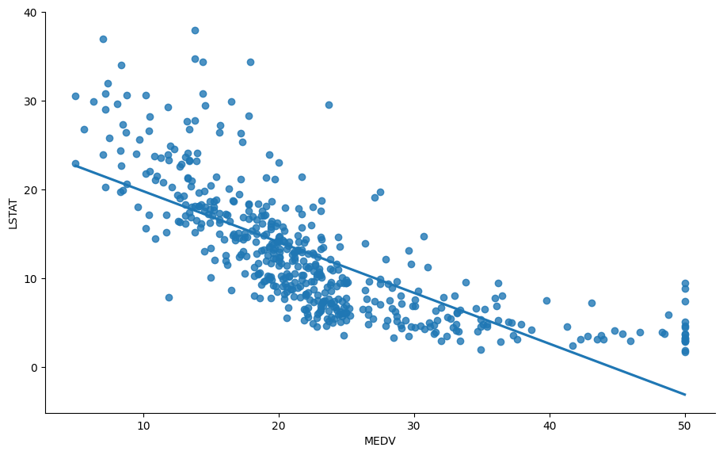

```python
#looking at the correlation between MEDV and LSTAT
sns.lmplot(x = 'MEDV', y = 'LSTAT', data = df, fit_reg = True, ci = None)
fig = plt.gcf()
fig.set_size_inches(10, 6)
plt.show()
```

**Observation:**

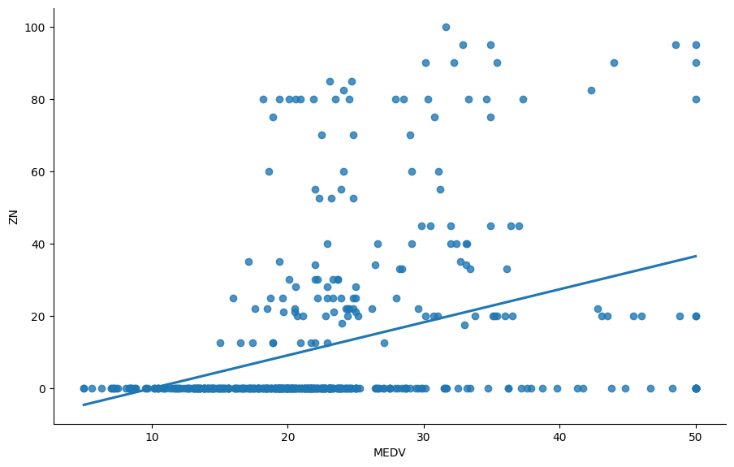

```python
#looking at the correlation between MEDV and ZN
sns.lmplot(x = 'MEDV', y = 'ZN', data = df, fit_reg = True, ci = None)
fig = plt.gcf()
fig.set_size_inches(10, 6)
plt.show()
```

**Observation:**

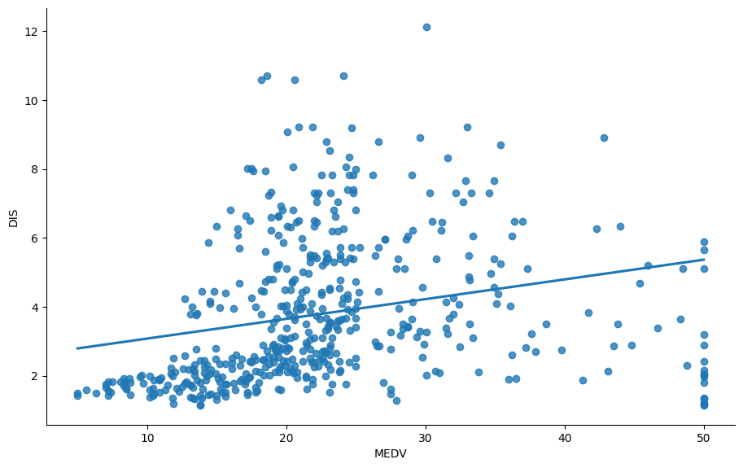

```python
#looking at the correlation between MEDV and DIS
sns.lmplot(x = 'MEDV', y = 'DIS', data = df, fit_reg = True, ci = None)
fig = plt.gcf()
fig.set_size_inches(10, 6)
plt.show()
```

**Observation**:

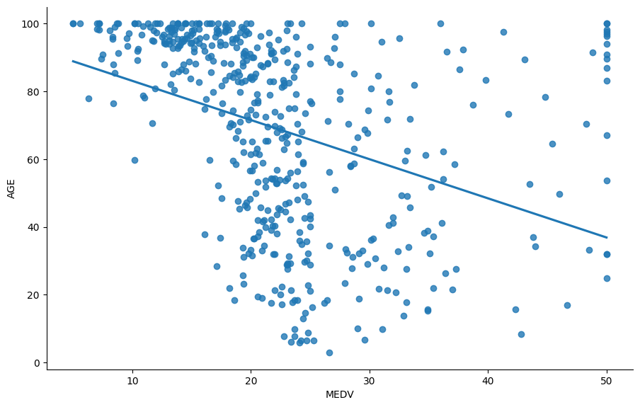

```python
#looking at the correlation between MEDV and AGE
sns.lmplot(x = 'MEDV', y = 'AGE', data = df, fit_reg = True, ci = None)
fig = plt.gcf()
fig.set_size_inches(10, 6)
plt.show()
```

**Observation**:

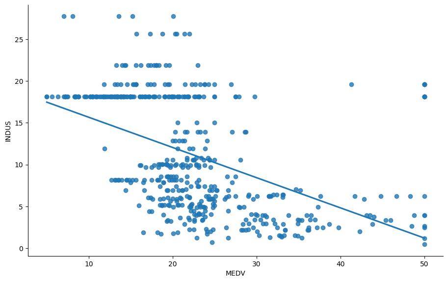

```python
   #looking at the correlation between MEDV and INDUS
sns.lmplot(x = 'MEDV', y = 'INDUS', data = df, fit_reg = True, ci = None)
fig = plt.gcf()
fig.set_size_inches(10, 6)
plt.show()
```

**Observation**:

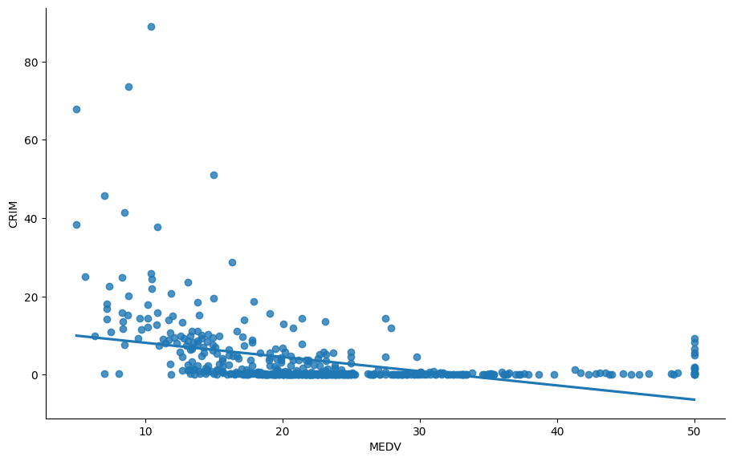

```python
#looking at the correlation between MEDV and RM
sns.lmplot(x = 'MEDV', y = 'CRIM', data = df, fit_reg = True, ci = None)
fig = plt.gcf()
fig.set_size_inches(10, 6)
plt.show()
```

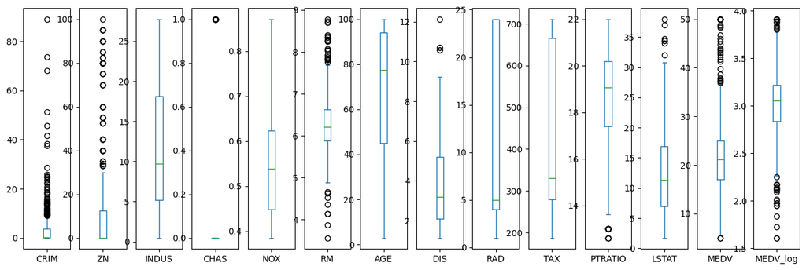

```python
# Box Plot to show ranges of values and outliers
df.plot(kind='box', subplots=True,  sharex=False, sharey=False,figsize=(16,5))
plt.show()
```

**Observation:**

- some attributes have outliers in ZN ,DIS,LSTAT, RM , CRIM , and CHAS.
- Missing value treatment
- Log transformation of dependent variable if skewed
- Feature engineering (if needed)
- Outlier detection and treatment (if needed)
- Preparing data for modeling
- Any other preprocessing steps (if needed)

## Splitting the data

will split the data into training and testing using a ratio of 70/30

```python
# Separating features and the target column
X = df.drop(['MEDV','MEDV_log'], axis = 1)
y = df['MEDV_log']
```

```python
X = sm.add_constant(X)
```

```python
# Splitting the data into train and test sets using 70:30 ratio
X_train, X_test, y_train, y_test = train_test_split(X, y, test_size = 0.30, random_state = 1)
```

## Multicollinearity Check

Multicollinearity is a potential problem for this regression. I will check it through Variance Inflation Factor (VIF). Features having a VIF score > 5 will be dropped/treated till all the features have a VIF score < 5

```python
import pandas as pd
import numpy as np
from statsmodels.stats.outliers_influence import variance_inflation_factor
```

```python
X_train1 = X_train.astype(float)
y_train1 = y_train.astype(float)

from statsmodels.stats.outliers_influence import variance_inflation_factor

# Function to check VIF
def checking_vif(train):
    vif = pd.DataFrame()
    vif["feature"] = train.columns

    # Calculating VIF for each feature
    vif["VIF"] = [
        variance_inflation_factor(train.values, i) for i in range(len(train.columns))
    ]
    return  vif.sort_values(by=['VIF']).reset_index(drop=True)

checking_vif(X_train)
```

|  | feature | VIF |
| --- | --- | --- |
| 0 | CHAS | 1.076564 |
| 1 | RM | 1.860950 |
| 2 | CRIM | 1.924114 |
| 3 | PTRATIO | 1.943409 |
| 4 | ZN | 2.743574 |
| 5 | LSTAT | 2.861881 |
| 6 | AGE | 3.150170 |
| 7 | INDUS | 3.999538 |
| 8 | DIS | 4.355469 |
| 9 | NOX | 4.396157 |
| 10 | RAD | 8.345247 |
| 11 | TAX | 10.191941 |
| 12 | const | 535.372593 |

**Observation:**

- RAD and TAX have the highest VIF greater than 5.
- let's remove TAX and check again.

```python
X_train1 = X_train1.drop('TAX',axis = 1)

X_test = X_test.drop('TAX',axis = 1)
```

```python
# apply VIF computation to all columns
from statsmodels.stats.outliers_influence import variance_inflation_factor

# Function to check VIF
def checking_vif(train):
    vif = pd.DataFrame()
    vif["feature"] = train.columns

    # Calculating VIF for each feature
    vif["VIF"] = [
        variance_inflation_factor(train.values, i) for i in range(len(train.columns))
    ]
    return vif.sort_values(by=['VIF']).reset_index(drop=True)


checking_vif(X_train1)
```

|  | feature | VIF |
| --- | --- | --- |
| 0 | CHAS | 1.050708 |
| 1 | RM | 1.857918 |
| 2 | PTRATIO | 1.909750 |
| 3 | CRIM | 1.923159 |
| 4 | ZN | 2.483399 |
| 5 | LSTAT | 2.860251 |
| 6 | RAD | 2.942862 |
| 7 | AGE | 3.149005 |
| 8 | INDUS | 3.270983 |
| 9 | DIS | 4.333734 |
| 10 | NOX | 4.361847 |
| 11 | const | 532.025529 |

**Observation:**

- now every predictor has less than 5 VIF.

## Model Building - Linear Regression - 1

```python
from sklearn.metrics import r2_score, mean_absolute_percentage_error, mean_absolute_error, mean_squared_error

# Model Performance on test and train data
def model_pref(olsmodel, x_train, x_test):

    # In-sample Prediction
    y_pred_train = olsmodel.predict(x_train)
    y_observed_train = y_train

    # Prediction on test data
    y_pred_test = olsmodel.predict(x_test)
    y_observed_test = y_test

    print(
        pd.DataFrame(
            {
                "Data": ["Train", "Test"],
                "RMSE": [
                    np.sqrt(mean_squared_error(y_pred_train, y_observed_train)),
                    np.sqrt(mean_squared_error(y_pred_test, y_observed_test)),
                ],
                "MAE": [
                    mean_absolute_error(y_pred_train, y_observed_train),
                    mean_absolute_error(y_pred_test, y_observed_test),
                ],

                "r2": [
                    r2_score(y_pred_train, y_observed_train),
                    r2_score(y_pred_test, y_observed_test),
                ],
            }
        )
    )
```

```python
X_train1 = X_train.astype(float)
y_train1 = y_train.astype(float)

# Create the model
model1 = sm.OLS(y_train1, X_train1).fit()

# Get the model summary
model1.summary()
```

OLS Regression Results

| Dep. Variable: | MEDV_log | R-squared: | 0.774 |
| --- | --- | --- | --- |
| Model: | OLS | Adj. R-squared: | 0.766 |
| Method: | Least Squares | F-statistic: | 97.19 |
| Date: | Tue, 30 Jul 2024 | Prob (F-statistic): | 3.27e-102 |
| Time: | 00:34:39 | Log-Likelihood: | 80.575 |
| No. Observations: | 354 | AIC: | -135.1 |
| Df Residuals: | 341 | BIC: | -84.85 |
| Df Model: | 12 |  |  |
| Covariance Type: | nonrobust |  |  |

|  | coef | std err | t | P>\|t\| | [0.025 | 0.975] |
| --- | --- | --- | --- | --- | --- | --- |
| const | 4.6856 | 0.241 | 19.404 | 0.000 | 4.211 | 5.161 |
| CRIM | -0.0129 | 0.002 | -7.579 | 0.000 | -0.016 | -0.010 |
| ZN | 0.0016 | 0.001 | 2.226 | 0.027 | 0.000 | 0.003 |
| INDUS | 0.0032 | 0.003 | 1.053 | 0.293 | -0.003 | 0.009 |
| CHAS | 0.1028 | 0.039 | 2.644 | 0.009 | 0.026 | 0.179 |
| NOX | -1.0141 | 0.186 | -5.462 | 0.000 | -1.379 | -0.649 |
| RM | 0.0509 | 0.021 | 2.471 | 0.014 | 0.010 | 0.091 |
| AGE | 0.0003 | 0.001 | 0.519 | 0.604 | -0.001 | 0.002 |
| DIS | -0.0523 | 0.010 | -5.126 | 0.000 | -0.072 | -0.032 |
| RAD | 0.0153 | 0.003 | 4.458 | 0.000 | 0.009 | 0.022 |
| TAX | -0.0005 | 0.000 | -2.784 | 0.006 | -0.001 | -0.000 |
| PTRATIO | -0.0427 | 0.007 | -6.299 | 0.000 | -0.056 | -0.029 |
| LSTAT | -0.0299 | 0.002 | -12.316 | 0.000 | -0.035 | -0.025 |

| Omnibus: | 34.291 | Durbin-Watson: | 1.980 |
| --- | --- | --- | --- |
| Prob(Omnibus): | 0.000 | Jarque-Bera (JB): | 88.992 |
| Skew: | 0.449 | Prob(JB): | 4.74e-20 |
| Kurtosis: | 5.286 | Cond. No. | 1.17e+04 |

Notes:  
[1] Standard Errors assume that the covariance matrix of the errors is correctly specified.  
[2] The condition number is large, 1.17e+04. This might indicate that there are  
strong multicollinearity or other numerical problems.

```python
# Checking model1 performance
X_test_with_const = sm.add_constant(X_test, has_constant='add')

# Checking model1 performance
model_pref(model1, X_train1, X_test_with_const)
```

```
    Data      RMSE       MAE        r2
0  Train  0.192713  0.140133  0.707630
1   Test  2.270184  1.972701 -1.970864
```

**Observation:**

## Model Building - Linear Regression - 2

```python
X_train1 = X_train1.drop(['INDUS','CHAS','AGE','RAD','TAX'], axis = 1)
```

```python
X_test1 = X_test.drop(['INDUS','CHAS','AGE','RAD'], axis = 1)
```

```python
X_train1 = X_train1.astype(float)
y_train1 = y_train.astype(float)

# Create the model
model2 = sm.OLS(y_train, X_train1).fit()

# Get the model summary
model2.summary()
```

OLS Regression Results

| Dep. Variable: | MEDV_log | R-squared: | 0.753 |
| --- | --- | --- | --- |
| Model: | OLS | Adj. R-squared: | 0.748 |
| Method: | Least Squares | F-statistic: | 150.4 |
| Date: | Tue, 30 Jul 2024 | Prob (F-statistic): | 6.73e-101 |
| Time: | 00:34:39 | Log-Likelihood: | 64.758 |
| No. Observations: | 354 | AIC: | -113.5 |
| Df Residuals: | 346 | BIC: | -82.56 |
| Df Model: | 7 |  |  |
| Covariance Type: | nonrobust |  |  |

|  | coef | std err | t | P>\|t\| | [0.025 | 0.975] |
| --- | --- | --- | --- | --- | --- | --- |
| const | 4.2432 | 0.225 | 18.862 | 0.000 | 3.801 | 4.686 |
| CRIM | -0.0101 | 0.002 | -6.535 | 0.000 | -0.013 | -0.007 |
| ZN | 0.0013 | 0.001 | 1.797 | 0.073 | -0.000 | 0.003 |
| NOX | -0.7567 | 0.156 | -4.847 | 0.000 | -1.064 | -0.450 |
| RM | 0.0743 | 0.020 | 3.635 | 0.000 | 0.034 | 0.115 |
| DIS | -0.0534 | 0.010 | -5.458 | 0.000 | -0.073 | -0.034 |
| PTRATIO | -0.0352 | 0.006 | -5.799 | 0.000 | -0.047 | -0.023 |
| LSTAT | -0.0296 | 0.002 | -12.725 | 0.000 | -0.034 | -0.025 |

| Omnibus: | 47.731 | Durbin-Watson: | 2.000 |
| --- | --- | --- | --- |
| Prob(Omnibus): | 0.000 | Jarque-Bera (JB): | 162.943 |
| Skew: | 0.549 | Prob(JB): | 4.14e-36 |
| Kurtosis: | 6.137 | Cond. No. | 665. |

Notes:  
[1] Standard Errors assume that the covariance matrix of the errors is correctly specified.

```python
# Checking model2 performance
model_pref(model2, X_train1, X_test1)
```

```
    Data      RMSE       MAE        r2
0  Train  0.201519  0.144119  0.671319
1   Test  0.192057  0.145170  0.675538
```

**Observation:**

## Checking Linear Regression Assumptions

## 1- checking the mean residuals

```python
residuals = model2.resid

np.mean(residuals)
```

```
-6.221012405780962e-15
```

**Observation:**

- the mean residual is close to zero.

## 2- Checking the homoscedasticity

- Homoscedasticity - If the residuals are symmetrically distributed across the regression line, then the data is said to be homoscedastic.
- Heteroscedasticity- - If the residuals are not symmetrically distributed across the regression line, then the data is said to be heteroscedastic. In this case, the residuals can form a funnel shape or any other non-symmetrical shape.
- We'll use `Goldfeldquandt Test` to test the following hypothesis with alpha = 0.05:
  - Null hypothesis: Residuals are homoscedastic
  - Alternate hypothesis: Residuals have heteroscedastic

```python
from statsmodels.stats.diagnostic import het_white

from statsmodels.compat import lzip

import statsmodels.stats.api as sms
```

```python
import statsmodels.stats.api as sms

from statsmodels.compat import lzip

name = ["F statistic", "p-value"]

test = sms.het_goldfeldquandt(y_train, X_train1)

lzip(name, test)
```

```
[('F statistic', 1.0730404929483441), ('p-value', 0.3236556088083933)]
```

**Observation:**

- the p-value is more than 0.05, we cannot reject the Null Hypothesis that the residuals are homoscedastic and the corresponding assumption is satisfied.

## 3- Linearity of variables

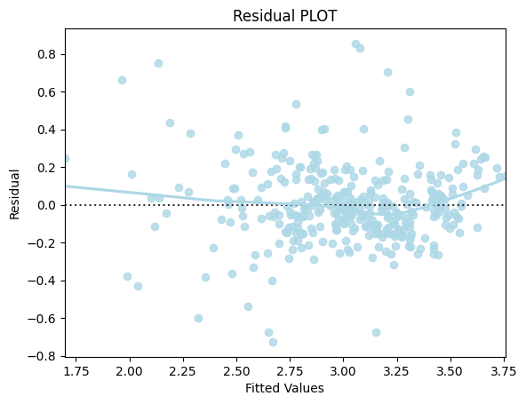

```python
# Predicted values
fitted = model2.fittedvalues

# sns.set_style("whitegrid")
sns.residplot(x = fitted, y = residuals, color = "lightblue", lowess = True)

plt.xlabel("Fitted Values")

plt.ylabel("Residual")

plt.title("Residual PLOT")

plt.show()
```

**Observation:**

- There is no pattern in the residual vs fitted values plot. Hence, the corresponding assumption is satisfied.

## 4. Normality of error terms

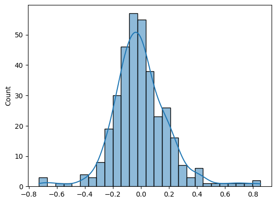

```python
# Plot histogram of residuals
sns.histplot(residuals, kde = True)
```

**Observation:**

- The residuals seem to follow a normal distribution. Hence, the corresponding assumption is satisfied.

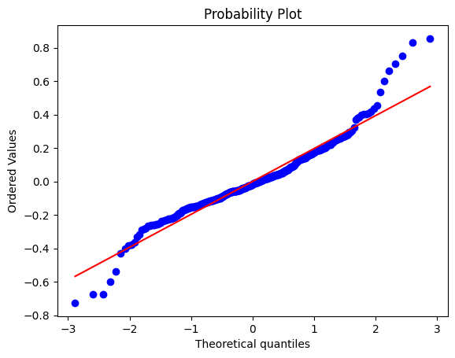

```python
# Plot q-q plot of residuals
import pylab

import scipy.stats as stats

stats.probplot(residuals, dist = "norm", plot = pylab)

plt.show()
```

- In order to make statistical inferences from a linear regression model, it is important to ensure that the assumptions of linear regression are satisfied.

## Model Performance Check

1. How does the model is performing? Check using Rsquared, RSME, MAE, MAPE
2. Is there multicollinearity? Check using VIF
3. How does the model is performing after cross validation?

```python
import numpy as np
import pandas as pd

# RMSE
def rmse(predictions, targets):
    return np.sqrt(((targets - predictions) ** 2).mean())

# MAPE
def mape(predictions, targets):
    return np.mean(np.abs((targets - predictions) / targets)) * 100

# MAE
def mae(predictions, targets):
    return np.mean(np.abs((targets - predictions)))

# Model Performance on test and train data
def model_pref(olsmodel, x_train, x_test, y_train, y_test):
    # In-sample Prediction
    y_pred_train = olsmodel.predict(x_train)
    y_observed_train = y_train

    # Prediction on test data
    y_pred_test = olsmodel.predict(x_test)
    y_observed_test = y_test

    results = pd.DataFrame(
        {
            "Data": ["Train", "Test"],
            "RMSE": [
                rmse(y_pred_train, y_observed_train),
                rmse(y_pred_test, y_observed_test),
            ],
            "MAE": [
                mae(y_pred_train, y_observed_train),
                mae(y_pred_test, y_observed_test),
            ],
            "MAPE": [
                mape(y_pred_train, y_observed_train),
                mape(y_pred_test, y_observed_test),
            ],
        }
    )
    print(results)
```

```python
    # Checking model performance
model_pref(model2, X_train1, X_test1, y_train, y_test)
```

```
    Data      RMSE       MAE      MAPE
0  Train  0.201519  0.144119  5.000552
1   Test  0.192057  0.145170  5.041418
```

Apply cross validation to improve the model and evaluate it using different evaluation metrics

```python
# Import the required function

from sklearn.model_selection import cross_val_score

# Build the regression model and cross-validate
linearregression = LinearRegression()

cv_Score11 = cross_val_score(linearregression, X_train, y_train, cv = 10)
cv_Score12 = cross_val_score(linearregression, X_train, y_train, cv = 10,
                             scoring = 'neg_mean_squared_error')


print("RSquared: %0.3f (+/- %0.3f)" % (cv_Score11.mean(), cv_Score11.std() * 2))
print("Mean Squared Error: %0.3f (+/- %0.3f)" % (-1*cv_Score12.mean(), cv_Score12.std() * 2))
```

```
RSquared: 0.733 (+/- 0.232)
Mean Squared Error: 0.041 (+/- 0.023)
```

**Observation:**

checking the coef for model 2 and Compare it with P-value

```python
coef = model2.params

pd.DataFrame({'Feature' : coef.index, 'Coefs' : coef.values})
```

|  | Feature | Coefs |
| --- | --- | --- |
| 0 | const | 4.243172 |
| 1 | CRIM | -0.010111 |
| 2 | ZN | 0.001288 |
| 3 | NOX | -0.756705 |
| 4 | RM | 0.074317 |
| 5 | DIS | -0.053361 |
| 6 | PTRATIO | -0.035182 |
| 7 | LSTAT | -0.029601 |

**Observation:**

- most the coefficients are statistically significant with P-values less than 0.05

## Actionable Insights and Recommendations

**Additional Information for Better Insights:**

- Real estate companies should look into houses built before 1940, as they may have been remodeled by their owners. Having this information can help achieve better pricing.